# Elasticità Domanda di Latte

Mattia Albertini

25/15/2022

## Descrizione

Questo R-Studio Script calcola l’elasticità della domanda aggregata di latte e dei rispettivi ricavi. Utilizzeremo lo stesso dataset dell’ultima volta, quindi prima calcoliamo la domanda aggregata, poi i ricavi ed infine le elasticità della domanda e dei ricavi.

## Set Up

Come al soluto prima installiamo i pacchetti che ci interessano.

Prima installa i paccketti togliendo “#” dal comando install.packages(“package_name”). Poi compila (schiaccia freccina verde) le libraries (attiva i pacchetti richiesti). Se li hai già installati, non farlo di nuovo sono già in memoria, installa solamente i pacchetti che non hai già.

Le libraries vanno compilate (o in gergo “runnate”, ovvero schiaccia il tastino verde) in ogni caso perché “attivano” i pacchetti.

```r
# Installa
#install.packages("tidyverse")
#install.packages("magrittr")
#install.packages("readxl")
#install.packages("cowplot")
#install.packages("plot3D")

# Attiva
library(tidyverse)
library(magrittr)
library(readxl)  # to upload from excel
library(cowplot) # to combine plots
library(plot3D)  # to graph 3D
```

Settate la directory come l’ultima volta (la location della cartella dove avete i dati):

```r
wd <- '/Users/mattiaalbertini/Library/CloudStorage/OneDrive-USI/Microeconomia A/Slides_Mattia/2024'
setwd(wd)
```

Infine, carichiamo i dati,

```r
milk <- read_excel("Domanda.xlsx", sheet = 1)
```

I dati dovrebbero essere alla tua destra alla voce “Data”.

## Domanda Aggregata

Ricalcoliamo la domanda aggregata partendo dalle domande individuali come l’ultima volta,

```r
milk$Q_tot <- rowSums(milk[,2:38])
data.frame(prezzo = milk$P, Q_tot = milk$Q_tot)
```

| prezzo | Q_tot |
| --- | --- |
| 6.00 | 5.5 |
| 4.00 | 18.0 |
| 2.00 | 47.0 |
| 0.50 | 109.0 |
| 0.25 | 189.0 |

Grafichiamola,

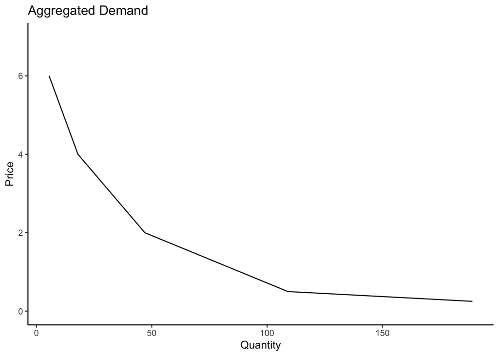

```r
agg_milk <- ggplot(data=milk) +   # Aggregated Demand (On 45 people)
  geom_line(aes(y = P, x= Q_tot))  +
  ylim(0, 7) +
  labs(x = "Quantity", y = "Price") +
  ggtitle("Aggregated Demand") +
  theme_classic()
agg_milk
```

Ora eliminiamo le domande individuali che non ci servono più, teniamo solo prezzo e quantità aggregate,

```r
milk[,2:38] <- NULL
milk
```

| P | Q_tot |
| --- | --- |
| 6.00 | 5.5 |
| 4.00 | 18.0 |
| 2.00 | 47.0 |
| 0.50 | 109.0 |
| 0.25 | 189.0 |

## Ricavi

Ora calcoliamo la curva dei ricavi, i.e. i valori di $P_i\cdot Q_i\hspace{0.2cm}\forall i$:

```r
milk$Revenue <- milk$P*milk$Q_tot
milk
```

| P | Q_tot | Revenue |
| --- | --- | --- |
| 6.00 | 5.5 | 33.00 |
| 4.00 | 18.0 | 72.00 |
| 2.00 | 47.0 | 94.00 |
| 0.50 | 109.0 | 54.50 |
| 0.25 | 189.0 | 47.25 |

Graficamente, sappiamo che i ricavi sono l’area del quadrato sottesa alla curva di domanda data una coppia $(Q,P)$, ovvero,

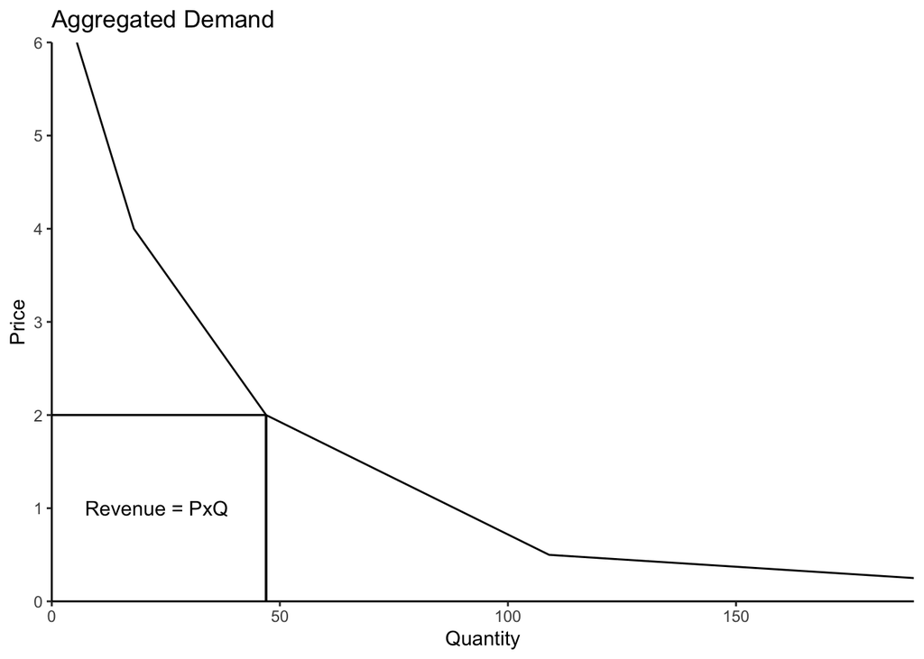

```r
agg_milk + geom_segment(aes(x = 0, y = 2, xend = 47, yend = 2)) +
           geom_segment(aes(x = 47, y = 0, xend = 47, yend = 2)) +
           annotate("text", x = 23, y = 1, label = "Revenue = PxQ") +
           scale_x_continuous(expand = c(0, 0)) + scale_y_continuous(expand = c(0, 0)) # technical stuff
```

Possiamo anche visualizzare rappresentare i ricavi in funzione del prezzo,

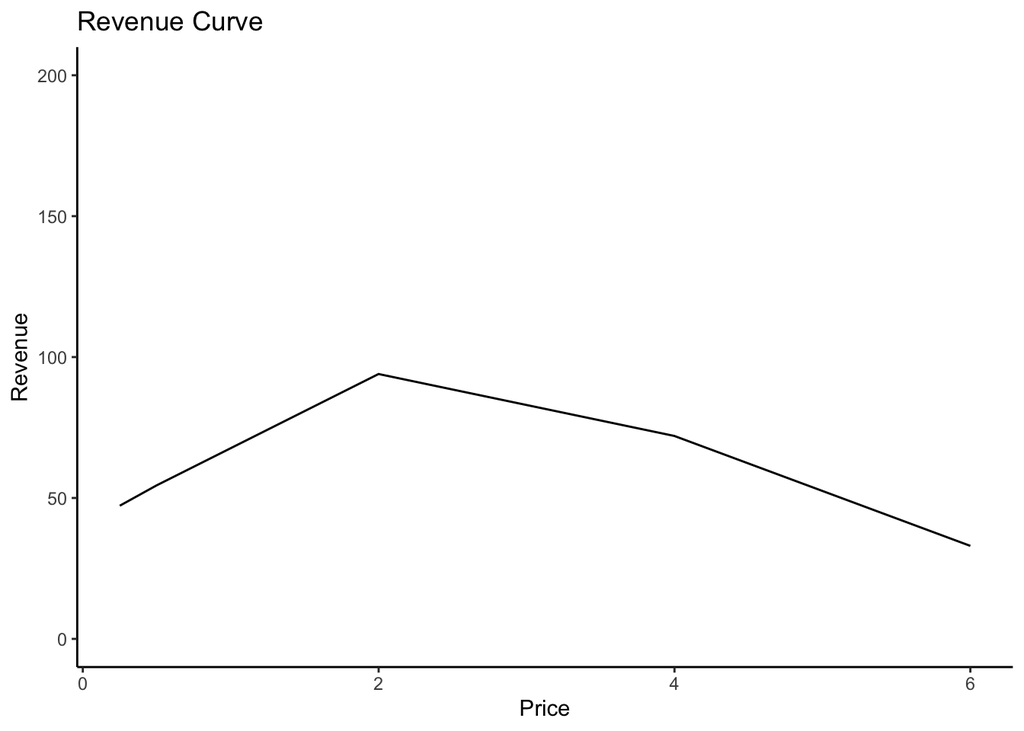

```r
rev_milk <- ggplot(data=milk) +   # Aggregated Demand (On 45 people)
  geom_line(aes(y = Revenue, x= P))  +
  ylim(0, 200) +
  labs(x = "Price", y = "Revenue") +
  ggtitle("Revenue Curve") +
  theme_classic()
rev_milk
```

Oppure in funzione sia del prezzo che della quantità,

```r
rev_milk3D <- scatter3D(x = milk$Q_tot, y = milk$P, z = milk$Revenue, phi = 0, bty = "g", type = "h", pch = 20, cex = 2, ticktype = "detailed", xlab = "quantity", ylab = "price", zlab = "revenue", main = "Revenue")
```

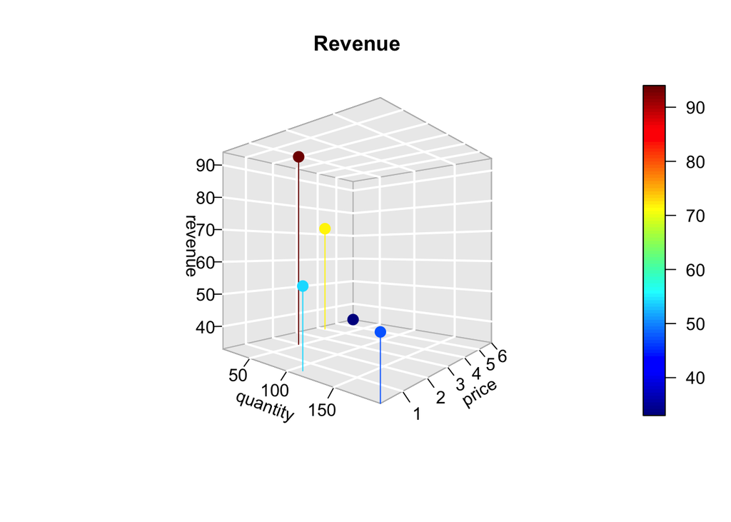

```r
rev_milk3D
```

[output not shown]

## Elasticità

Ora possiamo calcolare le elasticità. Perchè è importante? L’elasticità è una misura che ci permette di capire come le variazioni di prezzo influenzano le variazioni di quantità venduta. Dunque se varia il prezzo varia la quantità, e di conseguenza variano i ricavi (che sono una funzione di prezzo e quantità!): Se ad un economista aziendale viene chiesto dal maager “Pensi che sia una buona idea aumentare il prezzo del prodotto?” l’economista può calcolare la domanda aggregata del mercato, calcolarne l’elasticità e verificare se un aumento del prezzo si trasformerà in un aumento o perdita dei ricavi, e di conseguenza fornire una consulenza informata.

### Elasticità della Domanda

Ora, come sappiamo l’elasticità della domanda è data da,
$$E_D=\frac{\frac{\Delta Q}{Q}}{\frac{\Delta P}{P}}=\frac{\Delta Q}{\Delta
P}\cdot \frac{P}{Q}=\frac{1}{m}\cdot \frac{P}{Q}<0$$
Dove $m$ è il coefficiente angolare della domanda (se lineare) o della retta tangente nel punto (se la domanda è non lineare). Come sapete $E_D\in\{-\infty,0\}$ in quanto $m_D\leq 0$ e $P/Q\geq 0$ $\forall m,P,Q$.

Prendiamo la nostra domanda aggregata (non lineare),

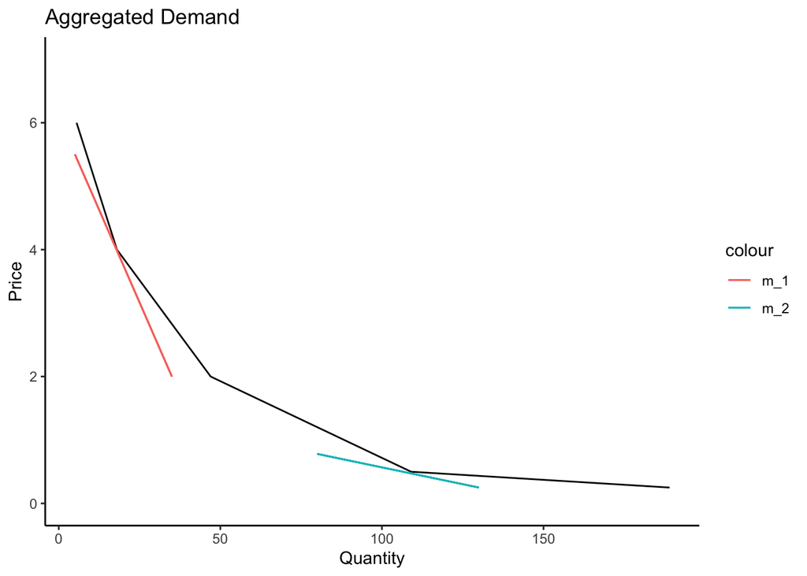

```r
agg_milk + geom_segment(aes(x = 5, y = 5.5, xend = 35, yend = 2, color = "m_1")) +
           geom_segment(aes(x = 80, y = 0.78, xend = 130, yend = 0.25, color = "m_2"))
```

Calcoliamo l’elasticità se il prezzo scende (dem_elast_down) e se il prezzo sale (elasticity_up) e aggiungiamola al nostro set di dati,

```r
# Initialize vectors
milk$dem_elast_down <- NA
milk$dem_elast_up   <- NA

# For loops
for (i in 1:4) {
  milk$dem_elast_down[i+1] <-(milk$Q_tot[i+1]-milk$Q_tot[i])/(milk$P[i+1]-milk$P[i])*milk$P[i]/milk$Q_tot[i]
}

for (i in 5:2) {
  milk$dem_elast_up[i-1] <-(milk$Q_tot[i-1]-milk$Q_tot[i])/(milk$P[i-1]-milk$P[i])*milk$P[i]/milk$Q_tot[i]
}
milk
```

| P | Q_tot | Revenue | dem_elast_down | dem_elast_up |
| --- | --- | --- | --- | --- |
| 6.00 | 5.5 | 33.00 | NA | -1.3888889 |
| 4.00 | 18.0 | 72.00 | -6.818182 | -0.6170213 |
| 2.00 | 47.0 | 94.00 | -3.222222 | -0.1896024 |
| 0.50 | 109.0 | 54.50 | -1.758865 | -0.4232804 |
| 0.25 | 189.0 | 47.25 | -1.467890 | NA |

Come vedete abbiamo due elasticità, diverse per ogni punto perchè $m_D$ cambia e diverse elasticità per aumenti o diminuzioni di prezzo. Per ovviare al problema di avere diverse elasticità a seconda di aumenti o diminuzioni di prezzo possiamo calcolare l’elasticità usando la fomula del punto medio,

$$E_D^m=\frac{\frac{\Delta Q}{\overline{Q}}}{\frac{\Delta
P}{\overline{P}}}=\frac{\Delta Q}{\Delta P}\cdot
\frac{\overline{P}}{\overline{Q}}=\frac{1}{m_D}\cdot\frac{\overline{P}}{\overline{Q}}$$
dove $\overline{P}=(P_1+P_2)/2$ e $\overline{Q}=(Q_1+Q_2)/2$. Ora aggiungiamo l’elasticità al nostro dataset (dem_elst_mean),

```r
# Initialize vector
milk$dem_elst_mean <- NA

# For loop
for (i in 1:4) {
  milk$dem_elst_mean[i+1] <- (milk$Q_tot[i+1]-milk$Q_tot[i])/(milk$P[i+1]-milk$P[i])*(milk$P[i+1]+milk$P[i])/(milk$Q_tot[i+1]+milk$Q_tot[i])
}
milk
```

| P | Q_tot | Revenue | dem_elast_down | dem_elast_up | dem_elst_mean |
| --- | --- | --- | --- | --- | --- |
| 6.00 | 5.5 | 33.00 | NA | -1.3888889 | NA |
| 4.00 | 18.0 | 72.00 | -6.818182 | -0.6170213 | -2.6595745 |
| 2.00 | 47.0 | 94.00 | -3.222222 | -0.1896024 | -1.3384615 |
| 0.50 | 109.0 | 54.50 | -1.758865 | -0.4232804 | -0.6623932 |
| 0.25 | 189.0 | 47.25 | -1.467890 | NA | -0.8053691 |

Come vedete avremo sempre un elasticità diversa a seconda del punto perchè $m_D$ cambia, ma questa misura è indipendente dalla direzione della variazione di prezzo.

### Elasticità dei Ricavi

$$E_R=1-|E_D|\hspace{0.2cm}\begin{cases}\leq 0 & \text{if} &
|E_D|\geq1 \\
>0 & \text{if} & |E_D|<1\end{cases}$$

Lascio a voi il calcolo dell’elasticità dei ricavi per aumenti/diminuzioni di prezzo usando questa formula ridotta. Calcoliamo invece l’elasticità del punto medio come,

$$E_D^m=\frac{\frac{\Delta R}{\overline{R}}}{\frac{\Delta
P}{\overline{P}}}=\frac{\Delta R}{\Delta P}\cdot
\frac{\overline{P}}{\overline{R}}=m_R\cdot\frac{\overline{P}}{\overline{R}}$$
dove $\overline{P}=(P_1+P_2)/2$ e $\overline{R}=(R_1+R_2)/2$, quindi,

```r
# Initialize vector
milk$rev_elst_mean <- NA

# For loop
for (i in 1:4) {
  milk$rev_elst_mean[i+1] <- (milk$Revenue[i+1]-milk$Revenue[i])/(milk$P[i+1]-milk$P[i])*(milk$P[i+1]+milk$P[i])/(milk$Revenue[i+1]+milk$Revenue[i])
}
milk
```

| P | Q_tot | Revenue | dem_elast_down | dem_elast_up | dem_elst_mean | rev_elst_mean |
| --- | --- | --- | --- | --- | --- | --- |
| 6.00 | 5.5 | 33.00 | NA | -1.3888889 | NA | NA |
| 4.00 | 18.0 | 72.00 | -6.818182 | -0.6170213 | -2.6595745 | -1.8571429 |
| 2.00 | 47.0 | 94.00 | -3.222222 | -0.1896024 | -1.3384615 | -0.3975904 |
| 0.50 | 109.0 | 54.50 | -1.758865 | -0.4232804 | -0.6623932 | 0.4433221 |
| 0.25 | 189.0 | 47.25 | -1.467890 | NA | -0.8053691 | 0.2137592 |